# Murray Logan's Stats Course

install.packages(‘knitr’)

Using library ‘markdown’

This will create a html output from the data. Can be used to write papers, so if you change the data, the paper will change with it.

A linear model consists of the intercept, slope and predictor. A linear model DOES NOT have to be a straigth line, it only means that there are No x in the power (eg y = ax + b). A non linear model does not imply that there are x only at the base (eg y = ab<sup>x)</sup>

I am experiencing lay-out problems: entering a newline or removing superscript formatting. www.flutterbys.com.au/stats/downloads/data/

Download 'fertilizer.csv'

```r
setwd("~/Documents/Monash/PhD/R")
fert <- read.csv('fertilizer.csv',strip.white=T)
```

It is good practise to enter the 'strip.white=T' command as this chomps off any white spaces in the document.

Give the first 6 lines of the data

```r
head(fert)
```

```
##   FERTILIZER YIELD
## 1         25    84
## 2         50    80
## 3         75    90
## 4        100   154
## 5        125   148
## 6        150   169
```

Also good practise to get the variables of the data

```r
str(fert)
```

```
## 'data.frame':    10 obs. of  2 variables:
##  $ FERTILIZER: int  25 50 75 100 125 150 175 200 225 250
##  $ YIELD     : int  84 80 90 154 148 169 206 244 212 248
```

So quickly explore the data it is also smart to get a summary

```r
summary(fert)
```

```
##    FERTILIZER         YIELD
##  Min.   : 25.00   Min.   : 80.0
##  1st Qu.: 81.25   1st Qu.:104.5
##  Median :137.50   Median :161.5
##  Mean   :137.50   Mean   :163.5
##  3rd Qu.:193.75   3rd Qu.:210.5
##  Max.   :250.00   Max.   :248.0
```

For the next section we need the package 'car'

When installing packages in knitr, it is important to set the mirror and location of the library

```r
install.packages("car", repos="http://cran.ms.unimelb.edu.au/")
library("car", lib.loc="/Library/Frameworks/R.framework/Versions/3.0/Resources/library")
```

Now make a scatterplot

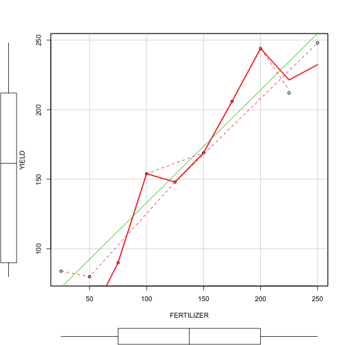

```r
scatterplot(YIELD~FERTILIZER,data=fert)
```

And run ggplot

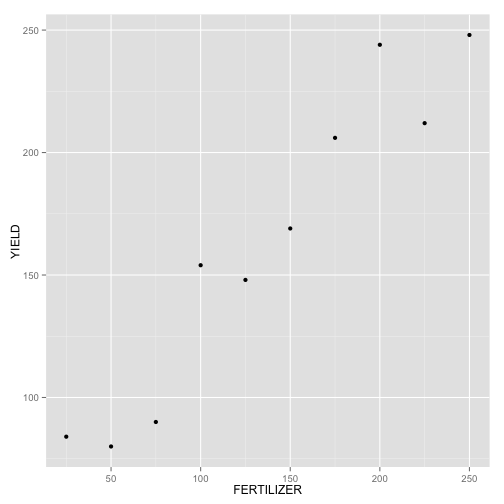

```r
ggplot(fert,aes(y=YIELD, x=FERTILIZER))+geom_point()
```

Different options in ggplot (white background)

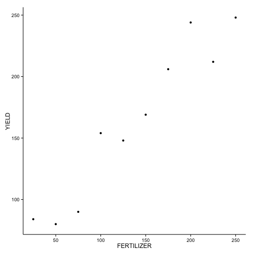

```r
ggplot(fert,aes(y=YIELD, x=FERTILIZER))+geom_point()+theme_classic()
```

Alter the scales

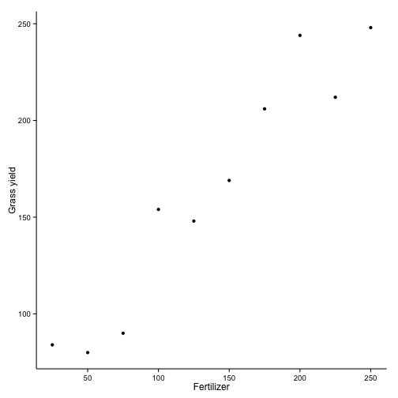

```r
ggplot(fert,aes(y=YIELD, x=FERTILIZER))+geom_point()+
  theme_classic()+
  scale_x_continuous('Fertilizer') +
  scale_y_continuous('Grass yield')
```

The order of commands is not important EXCEPT for the geometric features (each geometric layer is plotted in the order they are called).

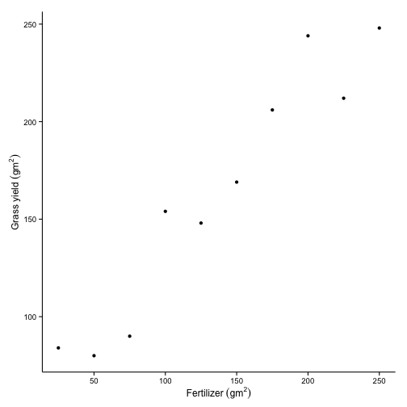

```r
ggplot(fert,aes(y=YIELD, x=FERTILIZER))+geom_point()+
  theme_classic()+
  scale_x_continuous(expression(Fertilizer~(g*m^2))) +
  scale_y_continuous(expression(Grass~yield~(g*m^2)))
```

To see which plotting expression options are available, type demo(plotmath)

These expressions need to be put into expression() to be transformed. Anywhere you want a space in between words, put a ~ instead

You can add items to your graphs like this

```r
p+geom_smooth(method='lm')
```

[output not shown]

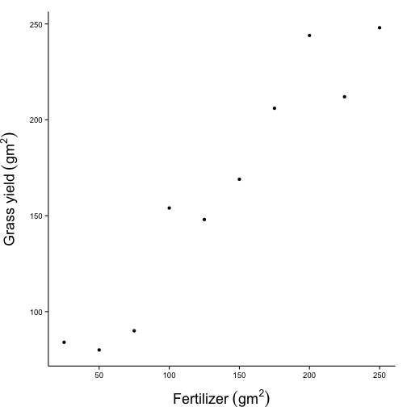

```r
p<-ggplot(fert,aes(y=YIELD, x=FERTILIZER))+geom_point()+
  theme_classic()+
  scale_x_continuous(expression(Fertilizer~(g*m^2))) +
  scale_y_continuous(expression(Grass~yield~(g*m^2)))
p+theme(axis.title.x=element_text(vjust=-1,size=rel(1.5)),
        axis.title.y=element_text(vjust=2,size=rel(1.5)))
```

```r
p<-p+theme(axis.title.x=element_text(vjust=-1,size=rel(1.5)),
        axis.title.y=element_text(vjust=2,size=rel(1.5)))
```

Add lines. Blue line is best fit for data, grey area is 95% confidence interval.

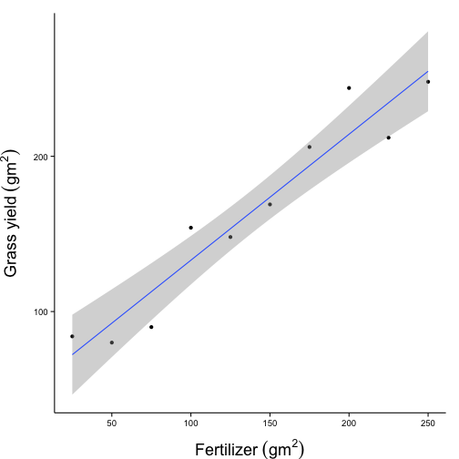

```r
p+geom_smooth(method='lm')
```

Will also run for general linear models

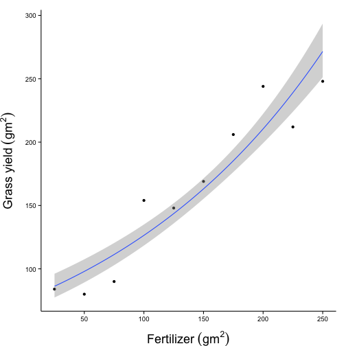

```r
p+geom_smooth(method='glm',formula=y~x,family='poisson')
```

And negative binomial (needs library MASS)

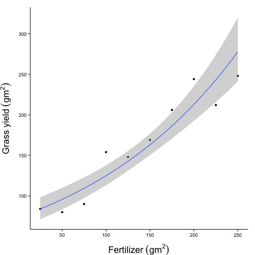

```r
p+geom_smooth(method='glm.nb',formula=y~x)
```

**Modelling**

Let's make some models:

```r
fert.lm<-lm(YIELD~FERTILIZER,data=fert)
```

Again look at the variables using extracter functions

```r
str(fert.lm)
```

```
## List of 12
##  $ coefficients : Named num [1:2] 51.933 0.811
##   ..- attr(*, "names")= chr [1:2] "(Intercept)" "FERTILIZER"
##  $ residuals    : Named num [1:10] 11.78 -12.5 -22.79 20.93 -5.36 ...
##   ..- attr(*, "names")= chr [1:10] "1" "2" "3" "4" ...
##  $ effects      : Named num [1:10] -517.03 184.25 -23.73 18.66 -8.96 ...
##   ..- attr(*, "names")= chr [1:10] "(Intercept)" "FERTILIZER" "" "" ...
##  $ rank         : int 2
##  $ fitted.values: Named num [1:10] 72.2 92.5 112.8 133.1 153.4 ...
##   ..- attr(*, "names")= chr [1:10] "1" "2" "3" "4" ...
##  $ assign       : int [1:2] 0 1
##  $ qr           :List of 5
##   ..$ qr   : num [1:10, 1:2] -3.162 0.316 0.316 0.316 0.316 ...
##   .. ..- attr(*, "dimnames")=List of 2
##   .. .. ..$ : chr [1:10] "1" "2" "3" "4" ...
##   .. .. ..$ : chr [1:2] "(Intercept)" "FERTILIZER"
##   .. ..- attr(*, "assign")= int [1:2] 0 1
##   ..$ qraux: num [1:2] 1.32 1.27
##   ..$ pivot: int [1:2] 1 2
##   ..$ tol  : num 1e-07
##   ..$ rank : int 2
##   ..- attr(*, "class")= chr "qr"
##  $ df.residual  : int 8
##  $ xlevels      : Named list()
##  $ call         : language lm(formula = YIELD ~ FERTILIZER, data = fert)
##  $ terms        :Classes 'terms', 'formula' length 3 YIELD ~ FERTILIZER
##   .. ..- attr(*, "variables")= language list(YIELD, FERTILIZER)
##   .. ..- attr(*, "factors")= int [1:2, 1] 0 1
##   .. .. ..- attr(*, "dimnames")=List of 2
##   .. .. .. ..$ : chr [1:2] "YIELD" "FERTILIZER"
##   .. .. .. ..$ : chr "FERTILIZER"
##   .. ..- attr(*, "term.labels")= chr "FERTILIZER"
##   .. ..- attr(*, "order")= int 1
##   .. ..- attr(*, "intercept")= int 1
##   .. ..- attr(*, "response")= int 1
##   .. ..- attr(*, ".Environment")=<environment: R_GlobalEnv>
##   .. ..- attr(*, "predvars")= language list(YIELD, FERTILIZER)
##   .. ..- attr(*, "dataClasses")= Named chr [1:2] "numeric" "numeric"
##   .. .. ..- attr(*, "names")= chr [1:2] "YIELD" "FERTILIZER"
##  $ model        :'data.frame':   10 obs. of  2 variables:
##   ..$ YIELD     : int [1:10] 84 80 90 154 148 169 206 244 212 248
##   ..$ FERTILIZER: int [1:10] 25 50 75 100 125 150 175 200 225 250
##   ..- attr(*, "terms")=Classes 'terms', 'formula' length 3 YIELD ~ FERTILIZER
##   .. .. ..- attr(*, "variables")= language list(YIELD, FERTILIZER)
##   .. .. ..- attr(*, "factors")= int [1:2, 1] 0 1
##   .. .. .. ..- attr(*, "dimnames")=List of 2
##   .. .. .. .. ..$ : chr [1:2] "YIELD" "FERTILIZER"
##   .. .. .. .. ..$ : chr "FERTILIZER"
##   .. .. ..- attr(*, "term.labels")= chr "FERTILIZER"
##   .. .. ..- attr(*, "order")= int 1
##   .. .. ..- attr(*, "intercept")= int 1
##   .. .. ..- attr(*, "response")= int 1
##   .. .. ..- attr(*, ".Environment")=<environment: R_GlobalEnv>
##   .. .. ..- attr(*, "predvars")= language list(YIELD, FERTILIZER)
##   .. .. ..- attr(*, "dataClasses")= Named chr [1:2] "numeric" "numeric"
##   .. .. .. ..- attr(*, "names")= chr [1:2] "YIELD" "FERTILIZER"
##  - attr(*, "class")= chr "lm"
```

```r
coef(fert.lm) #the coefficients of the linear model
```

```
## (Intercept)  FERTILIZER
##  51.9333333   0.8113939
```

```r
resid(fert.lm) #the residuals of each x value
```

```
##          1          2          3          4          5          6
##  11.781818 -12.503030 -22.787879  20.927273  -5.357576  -4.642424
##          7          8          9         10
##  12.072727  29.787879 -22.496970  -6.781818
```

Now start plotting. First prepare the graphical space with par(mfrow = c(2,3)). Plot all the diagnostic graphs of the model

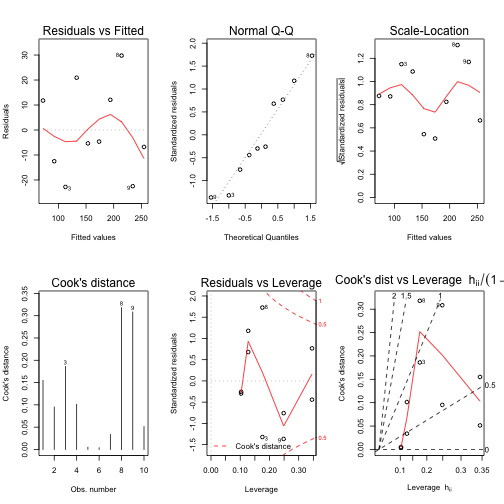

```r
par(mfrow = c(2,3))
plot(fert.lm,ask=F,which=1:6)
```

```r
#ask=F turns off the asking prompt
#which=1:6 will show the first 6 diagnostic graphs
```

plot [1,1] is the **residual plot**, the unexplained bit of the model. There should be no pattern in this plot. If there is a pattern, this can occur for several reasons: -wrong model is implied -unequal variance (will create wedge in residual box) -temporal autocorrelation (will produce horizontal stripes) A smoother (red line) will help you identify a potential pattern in the residuals

**q-q normal plot** [1,2] shows the normality of the data. If the data is exactly normal, all points will be exactly on the diagonal line. In itself the q-q plot is not too useful, only if residual plot doesn't make sense

**standarized residual plot** [1,3] is similar to the residual plot. This one should be looked at when you have preformed a correction for autocorrelation

**cook's distance** [2,1] looks at how much of an outlier the data is on BOTH the y and x-axis. The close cook's d is to 1, the more of an outlier it is. This is for each observation, sorted in your observation order

**leverage plots** [2,2] and [2,3] make up the cook's distance plots and show if the outliers are determined by outlier on the x and y-axis respectively.

**If** all of these diagnostic graphs don't show any problem, **only then** can you run the summary of the model

summary() like plot() is an overloaded function. This means that the output of these functions will differ depending on the data that is inputted. For example, a summary of a model or summary of a table.

```r
summary(fert.lm)
```

```
##
## Call:
## lm(formula = YIELD ~ FERTILIZER, data = fert)
##
## Residuals:
##    Min     1Q Median     3Q    Max
## -22.79 -11.07  -5.00  12.00  29.79
##
## Coefficients:
##             Estimate Std. Error t value Pr(>|t|)
## (Intercept) 51.93333   12.97904   4.001  0.00394 **
## FERTILIZER   0.81139    0.08367   9.697 1.07e-05 ***
## ---
## Signif. codes:  0 '***' 0.001 '**' 0.01 '*' 0.05 '.' 0.1 ' ' 1
##
## Residual standard error: 19 on 8 degrees of freedom
## Multiple R-squared:  0.9216, Adjusted R-squared:  0.9118
## F-statistic: 94.04 on 1 and 8 DF,  p-value: 1.067e-05
```

The **intercept** estimate shows if the intercept is equal to 0, there is almost never a biological interpretation for this The **slope** estimate shows if the slope is equal to 0 The **F-statistic** is the squared value of the t-value of the slope.

Can also look at confidence intervalls instead of p-values, as they are far more informative

```r
confint(fert.lm)
```

```
##                  2.5 %    97.5 %
## (Intercept) 22.0036246 81.863042
## FERTILIZER   0.6184496  1.004338
```

The interval doesn't overlap 0 and is for this reason the effect of the slope is significant

Open a new dataset that has some problems

```r
peake <- read.csv('peake.csv',strip.white=T)
head(peake)
```

```
##      AREA SPECIES INDIV
## 1  516.00       3    18
## 2  469.06       7    60
## 3  462.25       6    57
## 4  938.60       8   100
## 5 1357.15      10    48
## 6 1773.66       9   118
```

```r
str(peake)
```

```
## 'data.frame':    25 obs. of  3 variables:
##  $ AREA   : num  516 469 462 939 1357 ...
##  $ SPECIES: int  3 7 6 8 10 9 10 11 16 9 ...
##  $ INDIV  : int  18 60 57 100 48 118 148 214 225 283 ...
```

```r
summary(peake)
```

```
##       AREA            SPECIES       INDIV
##  Min.   :  462.2   Min.   : 3   Min.   :  18.0
##  1st Qu.: 1773.7   1st Qu.:10   1st Qu.: 148.0
##  Median : 4451.7   Median :14   Median : 338.0
##  Mean   : 7802.0   Mean   :15   Mean   : 446.9
##  3rd Qu.: 9287.7   3rd Qu.:21   3rd Qu.: 632.0
##  Max.   :27144.0   Max.   :25   Max.   :1402.0
```

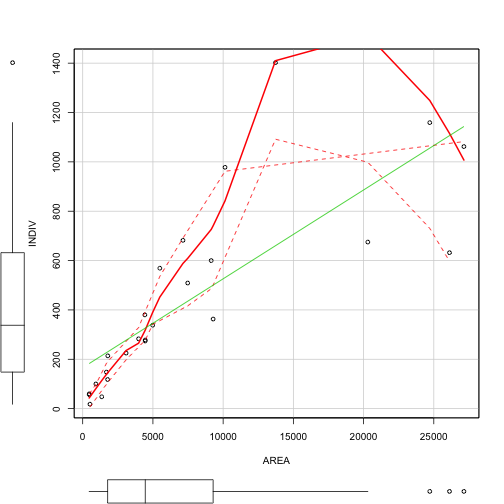

```r
scatterplot(INDIV~AREA,data=peake)
```

Now, this data is not normal distributed. So we need to do something explore this data.

First, transform the data

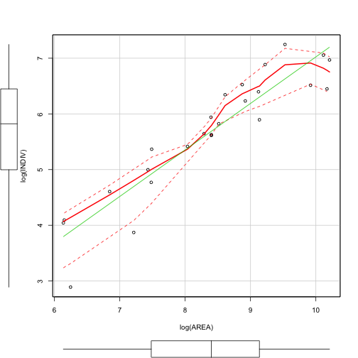

```r
scatterplot(log(INDIV)~log(AREA),data=peake)
```

This seems to have improved the data

Now fit a model reflecting the data

```r
peake.lm<-lm(log(INDIV)~log(AREA),data=peake)
str(peake.lm)
```

```
## List of 12
##  $ coefficients : Named num [1:2] -1.326 0.835
##   ..- attr(*, "names")= chr [1:2] "(Intercept)" "log(AREA)"
##  $ residuals    : Named num [1:25] -0.998 0.285 0.246 0.217 -0.825 ...
##   ..- attr(*, "names")= chr [1:25] "1" "2" "3" "4" ...
##  $ effects      : Named num [1:25] -28.243 5.05 0.306 0.317 -0.704 ...
##   ..- attr(*, "names")= chr [1:25] "(Intercept)" "log(AREA)" "" "" ...
##  $ rank         : int 2
##  $ fitted.values: Named num [1:25] 3.89 3.81 3.8 4.39 4.7 ...
##   ..- attr(*, "names")= chr [1:25] "1" "2" "3" "4" ...
##  $ assign       : int [1:2] 0 1
##  $ qr           :List of 5
##   ..$ qr   : num [1:25, 1:2] -5 0.2 0.2 0.2 0.2 0.2 0.2 0.2 0.2 0.2 ...
##   .. ..- attr(*, "dimnames")=List of 2
##   .. .. ..$ : chr [1:25] "1" "2" "3" "4" ...
##   .. .. ..$ : chr [1:2] "(Intercept)" "log(AREA)"
##   .. ..- attr(*, "assign")= int [1:2] 0 1
##   ..$ qraux: num [1:2] 1.2 1.31
##   ..$ pivot: int [1:2] 1 2
##   ..$ tol  : num 1e-07
##   ..$ rank : int 2
##   ..- attr(*, "class")= chr "qr"
##  $ df.residual  : int 23
##  $ xlevels      : Named list()
##  $ call         : language lm(formula = log(INDIV) ~ log(AREA), data = peake)
##  $ terms        :Classes 'terms', 'formula' length 3 log(INDIV) ~ log(AREA)
##   .. ..- attr(*, "variables")= language list(log(INDIV), log(AREA))
##   .. ..- attr(*, "factors")= int [1:2, 1] 0 1
##   .. .. ..- attr(*, "dimnames")=List of 2
##   .. .. .. ..$ : chr [1:2] "log(INDIV)" "log(AREA)"
##   .. .. .. ..$ : chr "log(AREA)"
##   .. ..- attr(*, "term.labels")= chr "log(AREA)"
##   .. ..- attr(*, "order")= int 1
##   .. ..- attr(*, "intercept")= int 1
##   .. ..- attr(*, "response")= int 1
##   .. ..- attr(*, ".Environment")=<environment: R_GlobalEnv>
##   .. ..- attr(*, "predvars")= language list(log(INDIV), log(AREA))
##   .. ..- attr(*, "dataClasses")= Named chr [1:2] "numeric" "numeric"
##   .. .. ..- attr(*, "names")= chr [1:2] "log(INDIV)" "log(AREA)"
##  $ model        :'data.frame':   25 obs. of  2 variables:
##   ..$ log(INDIV): num [1:25] 2.89 4.09 4.04 4.61 3.87 ...
##   ..$ log(AREA) : num [1:25] 6.25 6.15 6.14 6.84 7.21 ...
##   ..- attr(*, "terms")=Classes 'terms', 'formula' length 3 log(INDIV) ~ log(AREA)
##   .. .. ..- attr(*, "variables")= language list(log(INDIV), log(AREA))
##   .. .. ..- attr(*, "factors")= int [1:2, 1] 0 1
##   .. .. .. ..- attr(*, "dimnames")=List of 2
##   .. .. .. .. ..$ : chr [1:2] "log(INDIV)" "log(AREA)"
##   .. .. .. .. ..$ : chr "log(AREA)"
##   .. .. ..- attr(*, "term.labels")= chr "log(AREA)"
##   .. .. ..- attr(*, "order")= int 1
##   .. .. ..- attr(*, "intercept")= int 1
##   .. .. ..- attr(*, "response")= int 1
##   .. .. ..- attr(*, ".Environment")=<environment: R_GlobalEnv>
##   .. .. ..- attr(*, "predvars")= language list(log(INDIV), log(AREA))
##   .. .. ..- attr(*, "dataClasses")= Named chr [1:2] "numeric" "numeric"
##   .. .. .. ..- attr(*, "names")= chr [1:2] "log(INDIV)" "log(AREA)"
##  - attr(*, "class")= chr "lm"
```

```r
coef(peake.lm)
```

```
## (Intercept)   log(AREA)
##  -1.3263207   0.8349156
```

```r
resid(peake.lm)
```

```
##           1           2           3           4           5           6
## -0.99827974  0.28532404  0.24624123  0.21700315 -0.82484350 -0.14883198
##           7           8           9          10          11          12
##  0.12000954  0.44053515  0.03308160  0.05109573  0.25738403 -0.06021521
##          13          14          15          16          17          18
##  0.04109079 -0.07455441  0.48089427  0.11175433  0.44289111  0.10756519
##          19          20          21          22          23          24
##  0.51093621 -0.40743739  0.61750477 -0.44000565 -0.06359940 -0.22935072
##          25
## -0.71619315
```

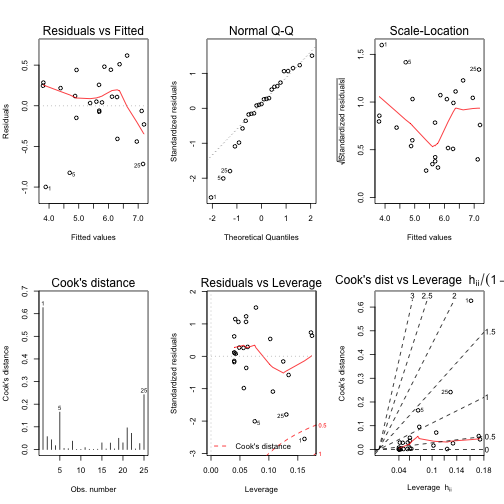

```r
par(mfrow = c(2,3))
plot(peake.lm,ask=F,which=1:6)
```

```r
summary(peake.lm)
```

```
##
## Call:
## lm(formula = log(INDIV) ~ log(AREA), data = peake)
##
## Residuals:
##     Min      1Q  Median      3Q     Max
## -0.9983 -0.1488  0.0511  0.2574  0.6175
##
## Coefficients:
##             Estimate Std. Error t value Pr(>|t|)
## (Intercept) -1.32632    0.59645  -2.224   0.0363 *
## log(AREA)    0.83492    0.07066  11.816 3.01e-11 ***
## ---
## Signif. codes:  0 '***' 0.001 '**' 0.01 '*' 0.05 '.' 0.1 ' ' 1
##
## Residual standard error: 0.4274 on 23 degrees of freedom
## Multiple R-squared:  0.8586, Adjusted R-squared:  0.8524
## F-statistic: 139.6 on 1 and 23 DF,  p-value: 3.007e-11
```

Great!

Now predict values based on the model, so we can plot

```r
#I first need to 'predict the model (as it was transformed)
xs <- seq(min(peake$AREA),max(peake$AREA),len=100)
#this will make a sequence of 100 points in between the minimum and maximum values
newdata <- data.frame(AREA=xs) #put this in a data frame
head(newdata)
```

```
##        AREA
## 1  462.2500
## 2  731.7629
## 3 1001.2759
## 4 1270.7888
## 5 1540.3017
## 6 1809.8146
```

```r
pred<-predict(peake.lm, newdata=newdata,interval='confidence')
head(pred)
```

```
##        fit      lwr      upr
## 1 3.796810 3.427534 4.166086
## 2 4.180329 3.868340 4.492318
## 3 4.442137 4.166685 4.717589
## 4 4.641150 4.391411 4.890888
## 5 4.801738 4.570995 5.032481
## 6 4.936365 4.720010 5.152719
```

```r
newdata<-cbind(newdata,pred) #cbind binds data according to columns
```

Now for each predicted valua there is a fitted value and a lower and upper confidence interval

And plot

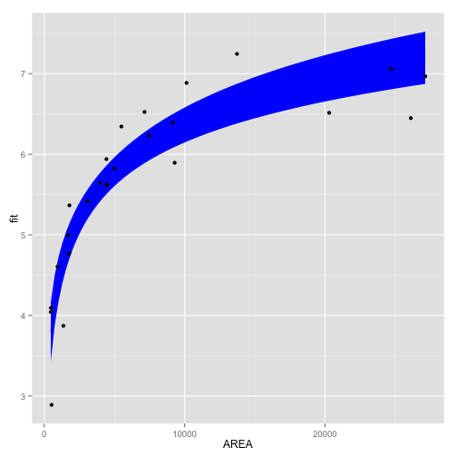

```r
ggplot(newdata,aes(y=fit, x=AREA)) +
  geom_line() +
  geom_ribbon(aes(ymin=lwr,ymax=upr),fill='blue') +
  geom_point(data=peake,aes(y=log(INDIV),x=AREA))
```

```r
   #confidence intervals, make sure to name the lower and upper!
```

**Multiple Linear Regression**

Regression with multiple predictor variables.

**Centering** of the data: calculating the mean of your x or y and subtracting this value from all of your individual values. This will also **reduce the correlation** between variables and also help to **convert** your model.

**Co-linearity**: you can't have predictors in the model that correlate to each other. To test this, take each predictor and test them against the other predictors. If there is an R<sup>2</sup> higher than .8, this is considered a correlation. We use 1-R<sup>2,</sup> the variance inflation. A variance inflation greater then 5 is generally considered a correlation (some people use 3). If there is a correlating predictor variable, this predictor can;t be in the same model as the others. **vif** will give this variance inflation between each predictor variable

Explore this with the next dataset

```r
loyn<-(read.csv('loyn.csv',strip.white=T))
head(loyn)
```

```
##   ABUND AREA YR.ISOL DIST LDIST GRAZE ALT
## 1   5.3  0.1    1968   39    39     2 160
## 2   2.0  0.5    1920  234   234     5  60
## 3   1.5  0.5    1900  104   311     5 140
## 4  17.1  1.0    1966   66    66     3 160
## 5  13.8  1.0    1918  246   246     5 140
## 6  14.1  1.0    1965  234   285     3 130
```

```r
str(loyn)
```

```
## 'data.frame':    56 obs. of  7 variables:
##  $ ABUND  : num  5.3 2 1.5 17.1 13.8 14.1 3.8 2.2 3.3 3 ...
##  $ AREA   : num  0.1 0.5 0.5 1 1 1 1 1 1 1 ...
##  $ YR.ISOL: int  1968 1920 1900 1966 1918 1965 1955 1920 1965 1900 ...
##  $ DIST   : int  39 234 104 66 246 234 467 284 156 311 ...
##  $ LDIST  : int  39 234 311 66 246 285 467 1829 156 571 ...
##  $ GRAZE  : int  2 5 5 3 5 3 5 5 4 5 ...
##  $ ALT    : int  160 60 140 160 140 130 90 60 130 130 ...
```

```r
summary(loyn)
```

```
##      ABUND            AREA            YR.ISOL          DIST
##  Min.   : 1.50   Min.   :   0.10   Min.   :1890   Min.   :  26.0
##  1st Qu.:12.40   1st Qu.:   2.00   1st Qu.:1928   1st Qu.:  93.0
##  Median :21.05   Median :   7.50   Median :1962   Median : 234.0
##  Mean   :19.51   Mean   :  69.27   Mean   :1950   Mean   : 240.4
##  3rd Qu.:28.30   3rd Qu.:  29.75   3rd Qu.:1966   3rd Qu.: 333.2
##  Max.   :39.60   Max.   :1771.00   Max.   :1976   Max.   :1427.0
##      LDIST            GRAZE            ALT
##  Min.   :  26.0   Min.   :1.000   Min.   : 60.0
##  1st Qu.: 158.2   1st Qu.:2.000   1st Qu.:120.0
##  Median : 338.5   Median :3.000   Median :140.0
##  Mean   : 733.3   Mean   :2.982   Mean   :146.2
##  3rd Qu.: 913.8   3rd Qu.:4.000   3rd Qu.:182.5
##  Max.   :4426.0   Max.   :5.000   Max.   :260.0
```

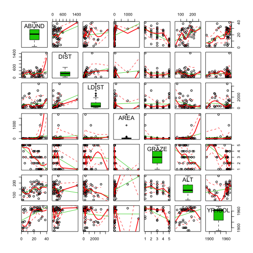

```r
scatterplotMatrix(~ABUND+DIST+LDIST+AREA+GRAZE+ALT+YR.ISOL,data=loyn,diagonal='boxplot')
```

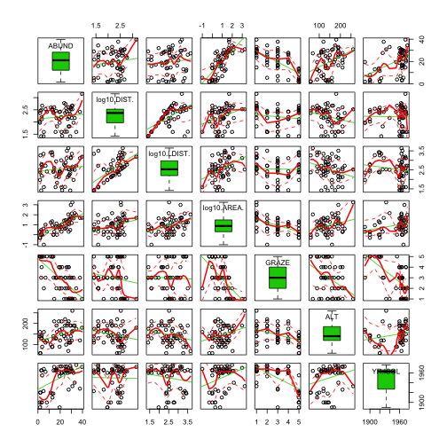

```r
#try to transform some of the data to achieve normality
scatterplotMatrix(~ABUND+log10(DIST)+log10(LDIST)+log10(AREA)+GRAZE+ALT+YR.ISOL,data=loyn,diagonal='boxplot')
```

Now make a model

```r
loyn.lm<-lm(ABUND~log10(DIST)+log10(LDIST)+log10(AREA)+GRAZE+ALT+YR.ISOL,data=loyn,
            na.action=na.fail)
```

And check the variance inflation

```r
vif(loyn.lm)
```

```
##  log10(DIST) log10(LDIST)  log10(AREA)        GRAZE          ALT
##     1.654553     2.009749     1.911514     2.524814     1.467937
##      YR.ISOL
##     1.804769
```

Produce the residual plots

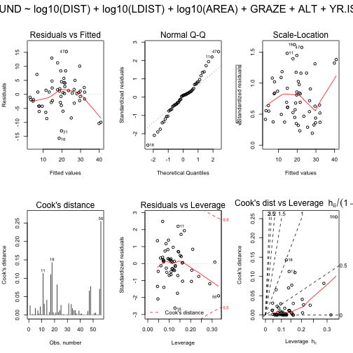

```r
par(mfrow=c(2,3),oma=c(0,0,2,0))
plot(loyn.lm,ask=F,which=1:6)
```

So looks OK

Get a summary of the model

```r
summary(loyn.lm)
```

```
##
## Call:
## lm(formula = ABUND ~ log10(DIST) + log10(LDIST) + log10(AREA) +
##     GRAZE + ALT + YR.ISOL, data = loyn, na.action = na.fail)
##
## Residuals:
##      Min       1Q   Median       3Q      Max
## -15.6506  -2.9390   0.5289   2.5353  15.2842
##
## Coefficients:
##                Estimate Std. Error t value Pr(>|t|)
## (Intercept)  -125.69725   91.69228  -1.371   0.1767
## log10(DIST)    -0.90696    2.67572  -0.339   0.7361
## log10(LDIST)   -0.64842    2.12270  -0.305   0.7613
## log10(AREA)     7.47023    1.46489   5.099 5.49e-06 ***
## GRAZE          -1.66774    0.92993  -1.793   0.0791 .
## ALT             0.01951    0.02396   0.814   0.4195
## YR.ISOL         0.07387    0.04520   1.634   0.1086
## ---
## Signif. codes:  0 '***' 0.001 '**' 0.01 '*' 0.05 '.' 0.1 ' ' 1
##
## Residual standard error: 6.384 on 49 degrees of freedom
## Multiple R-squared:  0.6849, Adjusted R-squared:  0.6464
## F-statistic: 17.75 on 6 and 49 DF,  p-value: 8.443e-11
```

Here, the estimates, the **partial slopes**, are the relationship between **each individual** predictor variable and the respones at the **means** of the other predictor variables.

The next step model selection. One way to do this is with the AIC. The smaller the AIC, the better

```r
AICc(loyn.lm)
```

[output not shown]

Need package MuMIn

Run the function dredge (needs the command na.action = na.fail in the model call)

```r
dredge(loyn.lm,rank="AICc")
```

```
## Global model call: lm(formula = ABUND ~ log10(DIST) + log10(LDIST) + log10(AREA) +
##     GRAZE + ALT + YR.ISOL, data = loyn, na.action = na.fail)
## ---
## Model selection table
##       (Int)     ALT    GRA l10(ARE) l10(DIS) l10(LDI)  YR.ISO df   logLik
## 39 -134.300         -1.902    7.166                   0.07835  5 -180.555
## 40 -141.900 0.02586 -1.601    7.076                   0.07991  6 -179.761
## 7    21.600         -2.854    6.890                            4 -182.257
## 55 -113.400         -1.842    7.751           -1.6460 0.06941  6 -180.036
## 47 -120.500         -1.939    7.487  -2.0480          0.07354  6 -180.072
## 23   25.740         -2.630    7.709           -2.1900          5 -181.347
## 38 -236.700 0.03623           8.150                   0.12480  5 -181.428
## 8    17.280 0.02468 -2.584    6.799                            5 -181.577
## 15   26.630         -2.827    7.298  -2.4750                   5 -181.582
## 37 -252.200                   8.593                   0.13520  4 -182.993
```

[output cut: 119 more lines]

This will show you the best model based on the AIC, and also the weights for each model, which can be used for model averaging (the best slope can be the **average** of the slopes predicted by different models)

```r
loyn.av<-model.avg(dredge(loyn.lm,rank="AICc"),
                   subset=delta<=2)
```

Get average coefficients

```r
summary(loyn.av)
```

```
##
## Call:
## model.avg.model.selection(object = dredge(loyn.lm, rank = "AICc"),
##     subset = delta <= 2)
##
## Component models:
##      df  logLik   AICc Delta Weight
## 236   5 -180.55 372.31  0.00   0.25
## 1236  6 -179.76 373.24  0.93   0.16
## 23    4 -182.26 373.30  0.99   0.15
## 2356  6 -180.04 373.79  1.48   0.12
## 2346  6 -180.07 373.86  1.55   0.11
## 235   5 -181.35 373.89  1.59   0.11
## 136   5 -181.43 374.06  1.75   0.10
##
## Term codes:
##          ALT        GRAZE  log10(AREA)  log10(DIST) log10(LDIST)
##            1            2            3            4            5
##      YR.ISOL
##            6
##
## Model-averaged coefficients:
##                Estimate Std. Error Adjusted SE z value Pr(>|z|)
## (Intercept)  -100.59988  108.90653   110.08735   0.914   0.3608
## GRAZE          -2.09737    0.94820     0.96603   2.171   0.0299 *
## log10(AREA)     7.37827    1.35872     1.38859   5.313    1e-07 ***
## YR.ISOL         0.08300    0.04594     0.04690   1.770   0.0767 .
## ALT             0.03000    0.02180     0.02230   1.345   0.1785
## log10(LDIST)   -1.91066    1.70048     1.74037   1.098   0.2723
## log10(DIST)    -2.04783    2.17582     2.22869   0.919   0.3582
##
## Full model-averaged coefficients (with shrinkage):
##                Estimate Std. Error Adjusted SE z value Pr(>|z|)
## (Intercept)  -1.006e+02  1.089e+02   1.101e+02   0.914   0.3608
## GRAZE        -1.881e+00  1.101e+00   1.115e+00   1.687   0.0917 .
## log10(AREA)   7.378e+00  1.359e+00   1.389e+00   5.313    1e-07 ***
## YR.ISOL       6.121e-02  5.376e-02   5.437e-02   1.126   0.2602
## ALT           7.753e-03  1.718e-02   1.735e-02   0.447   0.6549
## log10(LDIST) -4.393e-01  1.145e+00   1.159e+00   0.379   0.7046
## log10(DIST)  -2.331e-01  9.807e-01   9.942e-01   0.234   0.8146
## ---
## Signif. codes:  0 '***' 0.001 '**' 0.01 '*' 0.05 '.' 0.1 ' ' 1
##
## Relative variable importance:
##                      log10(AREA) GRAZE YR.ISOL ALT  log10(LDIST)
## Importance:          1.00        0.90  0.74    0.26 0.23
## N containing models:    7           6     5       2    2
##                      log10(DIST)
## Importance:          0.11
## N containing models:    1
```

Plot the added-variable plots

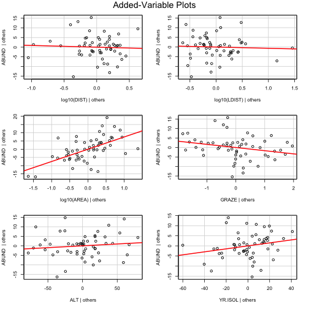

```r
avPlots(loyn.lm,ask=F)
```

The log10(AREA) plot shows the partial effect of area on abundance. The red line is the predicted trend if you hold all the other variables constant. The dots are the data that you would get if you held all of the other data constant.

Other way of showing this is in effects

Plot data

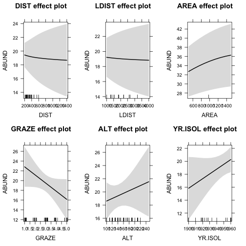

```r
plot(allEffects(loyn.lm,default.lecels=1000,ask=F))
```

Plot only the model that included important predictor variables

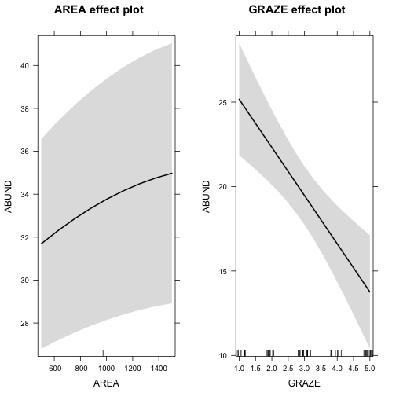

```r
loyn.lm1<-lm(ABUND~log10(AREA)+GRAZE,data=loyn)
plot(allEffects(loyn.lm1,default.lecels=1000,ask=F))
```

Get the effect of area at different grazing intesities

```r
newdata<-expand.grid(AREA=seq(1,2000,len=100),GRAZE=1:5)
#expand.grid repeats everything for each grazing intensity.
#This command should make us end up with a data frame with 500 rows
head(newdata)
```

```
##        AREA GRAZE
## 1   1.00000     1
## 2  21.19192     1
## 3  41.38384     1
## 4  61.57576     1
## 5  81.76768     1
## 6 101.95960     1
```

```r
pred<-predict(loyn.lm1,newdata=newdata,interval='confidence')
newdata<-cbind(newdata,pred)
head(newdata)
```

```
##        AREA GRAZE      fit      lwr      upr
## 1   1.00000     1 18.74931 13.80348 23.69515
## 2  21.19192     1 27.88673 24.91726 30.85620
## 3  41.38384     1 29.88941 26.96787 32.81094
## 4  61.57576     1 31.07849 28.09470 34.06227
## 5  81.76768     1 31.92715 28.85971 34.99460
## 6 101.95960     1 32.58754 29.43418 35.74090
```

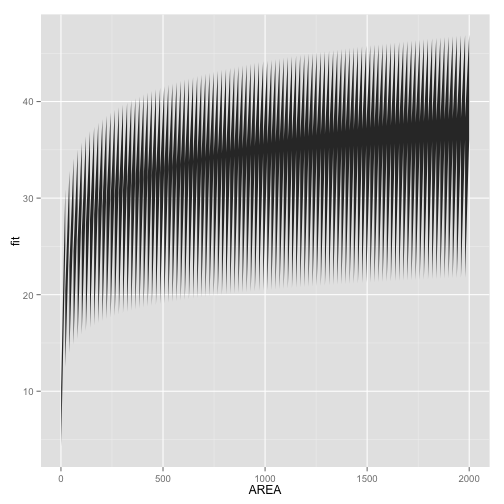

```r
ggplot(newdata,aes(y=fit,x=AREA)) +
  geom_ribbon(aes(ymin=lwr,ymax=upr))
```

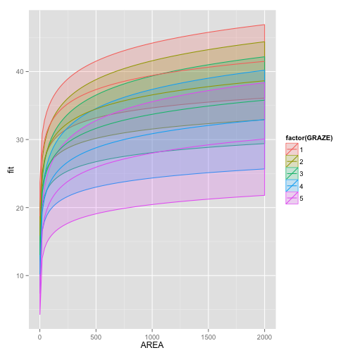

```r
ggplot(newdata,aes(y=fit,x=AREA,group=GRAZE,fill=factor(GRAZE),color=factor(GRAZE))) + geom_ribbon(aes(ymin=lwr,ymax=upr),alpha=0.2) + geom_line()
```

Get the predicted fitted values how area affects the response for each grazing cat.

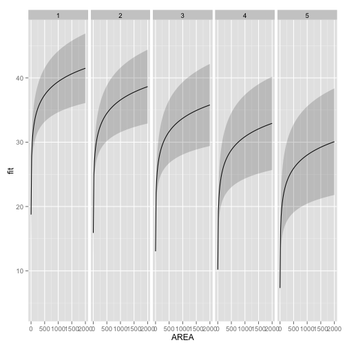

```r
ggplot(newdata,aes(y=fit,x=AREA))+facet_grid(~GRAZE) + geom_line() +
  geom_ribbon(aes(ymin=lwr,ymax=upr),alpha=0.2)
```

During the reporting of the data it is no longer required to show the best-fitting model. It is even possible to discuss multiple models.

Running an Anova

```r
day<-read.csv('day.csv',strip.white=T)
head(day)
```

```
##   TREAT BARNACLE
## 1  ALG1       27
## 2  ALG1       19
## 3  ALG1       18
## 4  ALG1       23
## 5  ALG1       25
## 6  ALG2       24
```

```r
summary(day)
```

```
##   TREAT      BARNACLE
##  ALG1:5   Min.   : 8.00
##  ALG2:5   1st Qu.:13.75
##  NB  :5   Median :19.50
##  S   :5   Mean   :19.75
##           3rd Qu.:25.25
##           Max.   :33.00
```

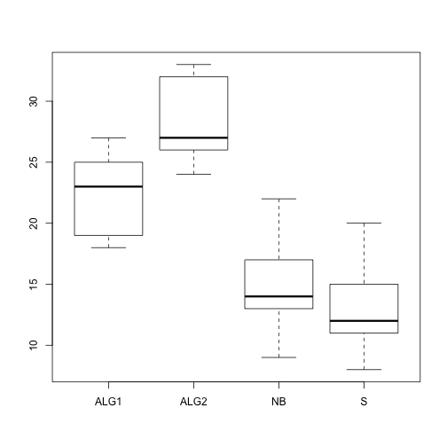

```r
boxplot(BARNACLE~TREAT,data=day)
```

To model an ANOVA just make a linear model. It has grown out of fashion to use aov()

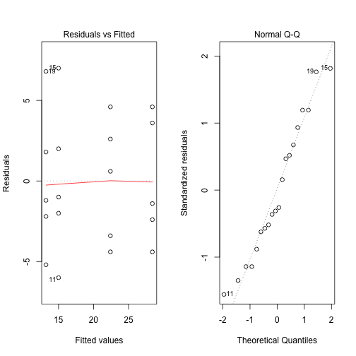

```r
day.lm<-lm(BARNACLE~TREAT,data=day)
par(mfrow=c(1,2))
plot(day.lm,ask=F,which=1:2)
```

Make sure residuals are centered. You can also plot the residuals against predictors that have not been included in the model (e.g. time) and look for patterns.

```r
summary(day.lm)
```

```
##
## Call:
## lm(formula = BARNACLE ~ TREAT, data = day)
##
## Residuals:
##    Min     1Q Median     3Q    Max
##  -6.00  -2.65  -1.10   2.85   7.00
##
## Coefficients:
##             Estimate Std. Error t value Pr(>|t|)
## (Intercept)   22.400      1.927  11.622 3.27e-09 ***
## TREATALG2      6.000      2.726   2.201  0.04275 *
## TREATNB       -7.400      2.726  -2.715  0.01530 *
## TREATS        -9.200      2.726  -3.375  0.00386 **
## ---
## Signif. codes:  0 '***' 0.001 '**' 0.01 '*' 0.05 '.' 0.1 ' ' 1
##
## Residual standard error: 4.31 on 16 degrees of freedom
## Multiple R-squared:  0.7125, Adjusted R-squared:  0.6586
## F-statistic: 13.22 on 3 and 16 DF,  p-value: 0.0001344
```

The intercept is average effect of the first treatment group. The second estimate (TREATALG2) is the effect of the second treatment group **compared** to treatment group 1.

Can also get the confidence intervals

```r
confint(day.lm)
```

```
##                   2.5 %    97.5 %
## (Intercept)  18.3140235 26.485977
## TREATALG2     0.2215566 11.778443
## TREATNB     -13.1784434 -1.621557
## TREATS      -14.9784434 -3.421557
```

Do pair-wise comparisons and corrections

```r
summary(glht(day.lm,linfct=mcp(TREAT="Tukey")))
```

```
##
##   Simultaneous Tests for General Linear Hypotheses
##
## Multiple Comparisons of Means: Tukey Contrasts
##
##
## Fit: lm(formula = BARNACLE ~ TREAT, data = day)
##
## Linear Hypotheses:
##                  Estimate Std. Error t value Pr(>|t|)
## ALG2 - ALG1 == 0    6.000      2.726   2.201   0.1653
## NB - ALG1 == 0     -7.400      2.726  -2.715   0.0661 .
## S - ALG1 == 0      -9.200      2.726  -3.375   0.0181 *
## NB - ALG2 == 0    -13.400      2.726  -4.916   <0.001 ***
## S - ALG2 == 0     -15.200      2.726  -5.576   <0.001 ***
## S - NB == 0        -1.800      2.726  -0.660   0.9103
## ---
## Signif. codes:  0 '***' 0.001 '**' 0.01 '*' 0.05 '.' 0.1 ' ' 1
## (Adjusted p values reported -- single-step method)
```

These comparisons should be independent of each other (autoginal)

**I missed a section here**

**Multi-factor ANOVA**

Factorial ANOVA includes an interaction. There are different possible scenarios.

```r
star<-read.csv('starling.csv',strip.white=T)
head(star)
```

```
##   SITUATION    MONTH MASS GROUP
## 1        S1 November   78 S1Nov
## 2        S1 November   88 S1Nov
## 3        S1 November   87 S1Nov
## 4        S1 November   88 S1Nov
## 5        S1 November   83 S1Nov
## 6        S1 November   82 S1Nov
```

```r
summary(star)
```

```
##  SITUATION      MONTH         MASS            GROUP
##  S1:20     January :40   Min.   : 68.00   S1Jan  :10
##  S2:20     November:40   1st Qu.: 78.75   S1Nov  :10
##  S3:20                   Median : 84.00   S2Jan  :10
##  S4:20                   Mean   : 83.80   S2Nov  :10
##                          3rd Qu.: 88.00   S3Jan  :10
##                          Max.   :100.00   S3Nov  :10
##                                           (Other):20
```

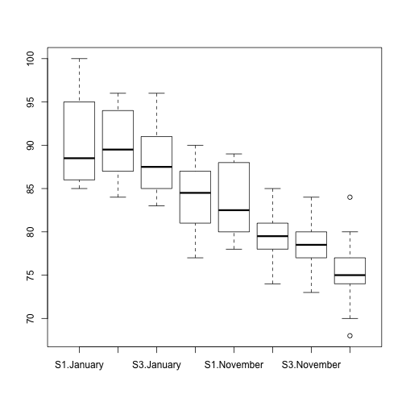

```r
boxplot(MASS~SITUATION*MONTH,data=star)
```

There are 8 combinations. Each combination has to be normally distributed. It looks good.

An ANOVA table shows how much of the variation in your data is explained by your predictor variables and their interaction. As the explained and unexplained variation are expressed in terms of each other, the replications need to be balanced (e.g. equal sample sizes). Look at this with

```r
replications(MASS~SITUATION*MONTH,data=star)
```

```
##       SITUATION           MONTH SITUATION:MONTH
##              20              40              10
```

So this dataset is balanced

Fit the model

```r
star.lm<-lm(MASS~SITUATION*MONTH,data=star)
```

And look at diagnostic plots

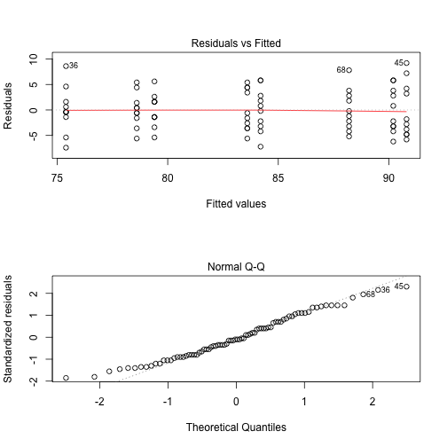

```r
par(mfrow=c(2,1))
plot(star.lm,ask=F,which=1:2)
```

In case of the following error: Error in plot.new() : figure margins too large

```r
dev.off()
```

And run again